# team

Kellan Bouwman

11/5/2020

## Lab 5

# Drunk Driving and Fatal Accidents

*Loading Files*

```r
library(dplyr)
```

```r
library(ggplot2)
library(tidyr)
library(readr)
library(classdata)
library(lubridate)
acc <- read.csv("https://raw.githubusercontent.com/xdaiISU/ds202materials/master/hwlabs/fars2017/accident.csv", stringsAsFactors = FALSE)
per <- read.csv("https://raw.githubusercontent.com/xdaiISU/ds202materials/master/hwlabs/fars2017/person.csv", stringsAsFactors = FALSE)

makeCode <- read.csv("makeCodes.csv")
stateCode <- read.csv("stateCodes.csv")
```

1. Are there some days of the week where more accidents happen than the others (see FARS manual, use variable DAY_WEEK)?

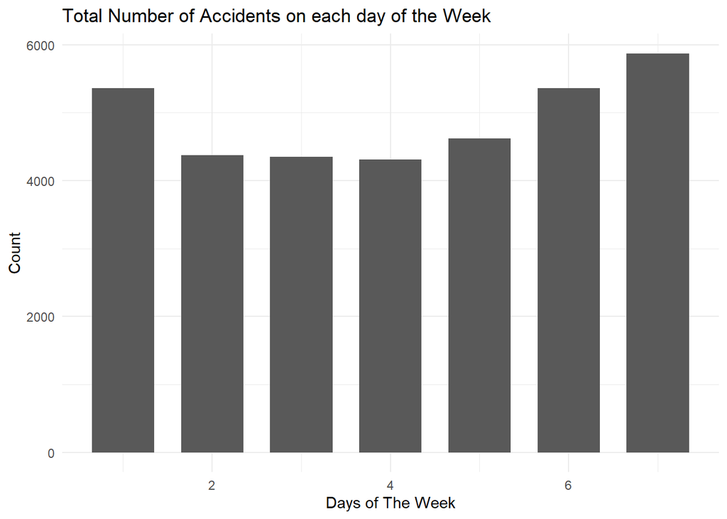

```r
accDays <- ggplot(acc, aes(DAY_WEEK)) + geom_bar(width=0.7) + theme_minimal()

print(accDays + labs(y="Count", x="Days of The Week", title = "Total Number of Accidents on each day of the Week"))
```

2. Create a data frame containing the persons who are fatally hurt in the accidents (look up variable INJ_SEV)
3. Create a data frame containing the most dangerous vehicle make in each state. The number of persons fatally hit in the vehicle make is used to assess the (non-)safety of a make. Make sure to handle the missing values appropriately. (look up variable MAKE)

```r
makeCode %>%
  mutate(MAKE = Codes) -> makeCode

stateCode %>%
  mutate(STATE = Code) -> stateCode

per %>%
  full_join(makeCode) -> per
per %>%
  full_join(stateCode) -> per
fatal<- per %>%
  filter(INJ_SEV == 2)

danger<- fatal %>%
  group_by(State, Make) %>%
  summarize(n = n()) %>%
  group_by(State) %>%
  filter(n == max(n))
print(danger)
```

```
## # A tibble: 54 x 3
## # Groups:   State [51]
##    State                Make          n
##    <chr>                <chr>     <int>
##  1 Alabama              Chevrolet    41
##  2 Alaska               Chevrolet     7
##  3 Arizona              Ford         51
##  4 Arkansas             Ford         18
##  5 California           Ford        147
##  6 Colorado             Ford         21
##  7 Connecticut          Ford         12
##  8 Delaware             Ford          7
##  9 District of Columbia Honda         2
## 10 District of Columbia Toyota        2
## # ... with 44 more rows
```

4. Create a map, and label each state with the most dangerous vehicle. Discuss the definition of the most dangerous vehicle, and what you find from the map. (Hint: Read the description for the STATE and COUNTY columns in the FARS manual. The state & county codes are Geographic Locator Codes (GLCs) from the General Services Administration’s (GSA) publication. Use readxl::read_xlsx to read in the GLCs.)
5. Join the accident and person table (work out which variable(s) to use)

   Joined by STATE, ST_CASE, VE_FORMS, COUNTY, DAY, MONTH, HOUR, MINUTE, RUR_URB, FUNC_SYS, HARM_E",MAN_COLL, SCH_BUS

```r
acc_per <- full_join(acc, per)
head(acc_per)
```

```
##   STATE ST_CASE VE_TOTAL VE_FORMS PVH_INVL PEDS PERNOTMVIT PERMVIT PERSONS
## 1     1   10001        1        1        0    0          0       1       1
## 2     1   10002        1        1        0    0          0       1       1
## 3     1   10003        3        3        0    0          0       3       3
## 4     1   10003        3        3        0    0          0       3       3
## 5     1   10003        3        3        0    0          0       3       3
## 6     1   10004        1        1        0    0          0       1       1
##   COUNTY CITY DAY MONTH YEAR DAY_WEEK HOUR MINUTE NHS RUR_URB FUNC_SYS RD_OWNER
## 1     73  330  19     2 2017        1   23     35   1       2        1        1
## 2     89 1730  14     2 2017        3   14     59   1       2        1        1
## 3    101 2130  31     1 2017        3   20     31   1       2        1        1
## 4    101 2130  31     1 2017        3   20     31   1       2        1        1
## 5    101 2130  31     1 2017        3   20     31   1       2        1        1
## 6     73  350   1     1 2017        1   16     55   0       2        4        4
##   ROUTE        TWAY_ID       TWAY_ID2 MILEPT LATITUDE  LONGITUD SP_JUR HARM_EV
```

[output cut: 69 more lines]

6. Tally the number of accidents by day of the week (DAY_WEEK), hour of the day (HOUR) and gender (SEX). Visualize the results.
7. Now plot a choropleth map of the number of deaths on a county level.
8. Is summer or winter more dangerous? Does this depend on states? Explore and explain.